# Optimization

MACS 33001 University of Chicago

## Optimization

- Method for selecting the best element (based on some criterion) from some set of available alternatives
- Maximizing/minimizing a function via systematic selection
- Given a function $f: A \rightarrow \Re$ from some set $A$ to the real numbers, we seek to determine an element $x_0 \in A$ such that
  - $f(x_0) \leq f(x)$ for all $x \in A$
  - $f(x_0) \geq f(x)$ for all $x \in A$
- $A$ is some subset of $\Re^n$
- Domain of $A$ is called the **search space**
- Elements of $A$ are called **candidate solutions**
- Function $f$
  - Objective function
  - Loss or cost function (minimization)
  - Utility or fitness function (maximization)

## Analytical solution for single variable functions

1. Find $f'(x)$
2. Set $f'(x)=0$ and solve for $x$. Call all $x_0$ such that $f'(x_0)=0$ **critical values**
3. Find $f''(x)$. Evaluate at each $x_0$
   - If $f''(x) > 0$, concave up, and therefore a local minimum
   - If $f''(x) < 0$, concave down, and therefore a local maximum
   - If it’s the global maximum/minimum, it will produce the largest/smallest value for $f(x)$
   - On a closed range along the domain, check the endpoints as well

## $f(x) = -x^2$, $x \in [-3, 3]$

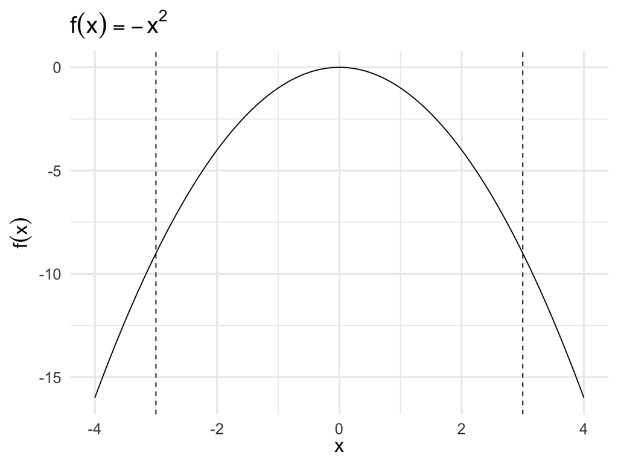

## $f(x) = -x^2$, $x \in [-3, 3]$

##### Critical Value

$$\begin{eqnarray}
f'(x) & = & - 2 x \\
0 & = & - 2 x^{*} \\
x^{*} & = & 0
\end{eqnarray}$$

##### Second Derivative

$$\begin{eqnarray}
f^{'}(x) & = & - 2x \\
f^{''}(x) & = & - 2
\end{eqnarray}$$

- $f^{''}(x)< 0$, local maximum

## $f(x) = x^3$, $x \in [-3, 3]$

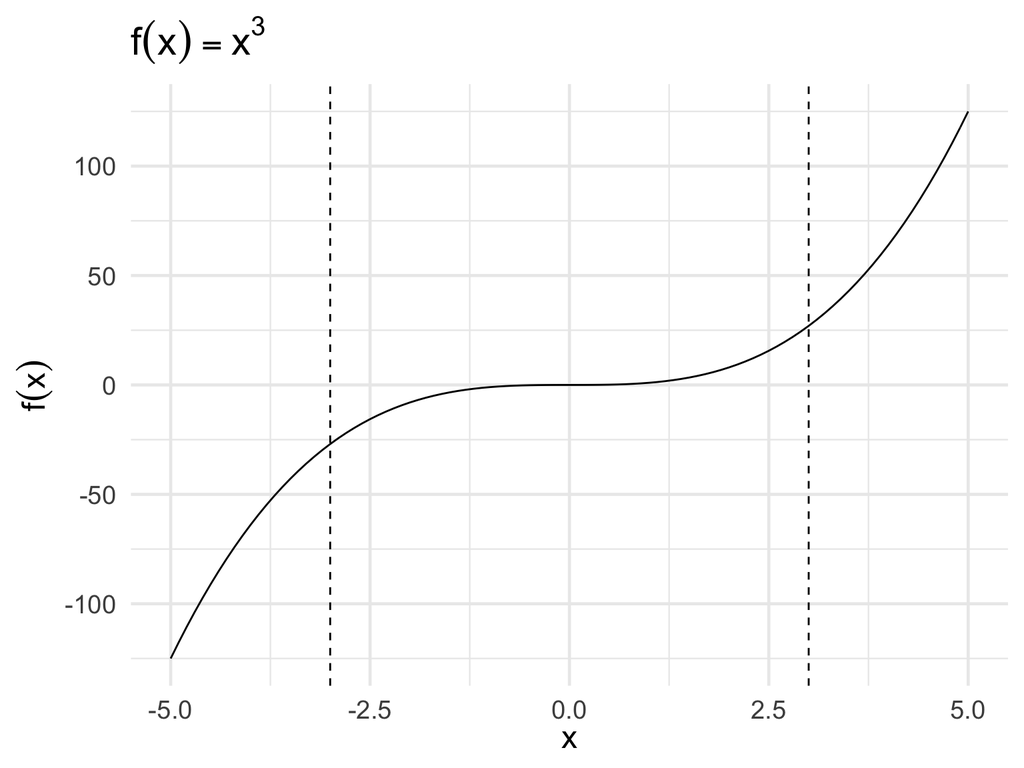

## $f(x) = x^3$, $x \in [-3, 3]$

##### Critical Value

$$\begin{eqnarray}
f'(x) & = & 3 x^2 \\
0 & = & 3 (x^{*})^2 \\
x^{*} & = & 0
\end{eqnarray}$$

##### Second Derivative

$$\begin{eqnarray}
f^{''}(x) & = & 6x \\
f^{''}(0) & = & 0
\end{eqnarray}$$

- Neither a minimum nor a maximum, it is a **saddle point**

## Differences from single variable optimization procedure

- Let $f:X \rightarrow \Re$ with $X \subset \Re^{n}$. A vector $\boldsymbol{x}^{*} \in X$ is a **global maximum** if , for all other $\boldsymbol{x} \in X$

  $$\begin{eqnarray}
  f(\boldsymbol{x}^{*}) & > & f(\boldsymbol{x} ) \nonumber
  \end{eqnarray}$$
- A vector $\boldsymbol{x}^{\text{local}}$ is a **local** maximum if there is a neighborhood around $\boldsymbol{x}^{\text{local}}$, $Q \subset X$ such that, for all $x \in Q$,

  $$\begin{eqnarray}
  f(\boldsymbol{x}^{\text{local} }) & > & f(\boldsymbol{x} )
  \end{eqnarray}$$

## First derivative test: Gradient

  $$\begin{eqnarray}
  \nabla f (\boldsymbol{x}_{0}) & = & \left(\frac{\partial f (\boldsymbol{x}_{0}) }{\partial x_{1} }, \frac{\partial f (\boldsymbol{x}_{0}) }{\partial x_{2} }, \frac{\partial f (\boldsymbol{x}_{0}) }{\partial x_{3} }, \ldots, \frac{\partial f (\boldsymbol{x}_{0}) }{\partial x_{n} } \right)
  \end{eqnarray}$$
- It is the first partial derivatives for each variable $x_n$ stored in a vector. So if $\boldsymbol{a} \in X$ is a **local** extremum, then,

  $$\begin{eqnarray}
  \nabla f(\boldsymbol{a}) & = & \boldsymbol{0} \\
  & = & (0, 0, \ldots, 0)
  \end{eqnarray}$$

## Example gradients

$$\begin{eqnarray}
f(x,y) &=& x^2+y^2 \\
\nabla f(x,y) &=& (2x, \, 2y)
\end{eqnarray}$$

$$\begin{eqnarray}
f(x,y) &=& x^3 y^4 +e^x -\log y \\
\nabla f(x,y) &=& (3x^2 y^4 + e^x, \, 4x^3y^3 - \frac{1}{y})
\end{eqnarray}$$

## Critical values

1. Maximum
2. Minimum
3. Saddle point

## Second derivative test: Hessian

- Suppose $f:X \rightarrow \Re^{1}$ , $X \subset \Re^{n}$, with $f$ a twice differentiable function. We will define the **Hessian** matrix as the matrix of second derivatives at $\boldsymbol{x}^{*} \in X$,

  $$\begin{eqnarray}
  \boldsymbol{H}(f)(\boldsymbol{x}^{*} ) & = & \begin{pmatrix}
  \frac{\partial^{2} f }{\partial x_{1} \partial x_{1} } (\boldsymbol{x}^{*} ) & \frac{\partial^{2} f }{\partial x_{1} \partial x_{2} } (\boldsymbol{x}^{*} ) & \ldots & \frac{\partial^{2} f }{\partial x_{1} \partial x_{n} } (\boldsymbol{x}^{*} ) \\
  \frac{\partial^{2} f }{\partial x_{2} \partial x_{1} } (\boldsymbol{x}^{*} ) & \frac{\partial^{2} f }{\partial x_{2} \partial x_{2} } (\boldsymbol{x}^{*} ) & \ldots & \frac{\partial^{2} f }{\partial x_{2} \partial x_{n} } (\boldsymbol{x}^{*} ) \\
  \vdots & \vdots & \ddots & \vdots \\
  \frac{\partial^{2} f }{\partial x_{n} \partial x_{1} } (\boldsymbol{x}^{*} ) & \frac{\partial^{2} f }{\partial x_{n} \partial x_{2} } (\boldsymbol{x}^{*} ) & \ldots & \frac{\partial^{2} f }{\partial x_{n} \partial x_{n} } (\boldsymbol{x}^{*} ) \\
  \end{pmatrix} \nonumber
  \end{eqnarray}$$
- Requires differentiating on the entire gradient with respect to each $x_n$

## Example Hessians

$$\begin{eqnarray}
f(x,y) &=& x^2+y^2 \\
\nabla f(x,y) &=& (2x, \, 2y) \\
\boldsymbol{H}(f)(x,y) &=& \begin{pmatrix}
2 & 0 \\
0 & 2
\end{pmatrix}
\end{eqnarray}$$

$$\begin{eqnarray}
f(x,y) &=& x^3 y^4 +e^x -\log y \\
\nabla f(x,y) &=& (3x^2 y^4 + e^x, \, 4x^3y^3 - \frac{1}{y}) \\
\boldsymbol{H}(f)(x,y) &=& \begin{pmatrix}
6xy^4 + e^x & 12x^2y^3 \\
12x^2y^3 & 12x^3y^2 + \frac{1}{y^2}
\end{pmatrix}
\end{eqnarray}$$

## Definiteness of a matrix

- Consider $n \times n$ matrix $\boldsymbol{A}$. If, for all $\boldsymbol{x} \in \Re^{n}$ where $\boldsymbol{x} \neq 0$:

  $$\begin{eqnarray}
  \boldsymbol{x}^{'} \boldsymbol{A} \boldsymbol{x} & > & 0, \quad \text{ $\boldsymbol{A}$ is positive definite } \\
  \boldsymbol{x}^{'} \boldsymbol{A} \boldsymbol{x} & < & 0, \quad \text{ $\boldsymbol{A}$ is negative definite }
  \end{eqnarray}$$
- If $\boldsymbol{x}^{'} \boldsymbol{A} \boldsymbol{x} >0$ for some $\boldsymbol{x}$ and $\boldsymbol{x}^{'} \boldsymbol{A} \boldsymbol{x}<0$ for other $\boldsymbol{x}$, then we say $\boldsymbol{A}$ is indefinite.

## Use the determinant to assess definiteness

$$\begin{eqnarray}
\boldsymbol{H}(f)(\boldsymbol{a}) & = & \begin{pmatrix}
A & B \\
B & C \\
\end{pmatrix}
\end{eqnarray}$$

- $AC - B^2> 0$ and $A>0$ $\leadsto$ positive definite $\leadsto$ $\boldsymbol{a}$ is a local minimum
- $AC - B^2> 0$ and $A<0$ $\leadsto$ negative definite $\leadsto$ $\boldsymbol{a}$ is a local maximum
- $AC - B^2<0$ $\leadsto$ indefinite $\leadsto$ saddle point
- $AC- B^2 = 0$ inconclusive

## Basic procedure summarized

1. Calculate gradient
2. Set equal to zero, solve system of equations
3. Calculate Hessian
4. Assess Hessian at critical values
5. Boundary values? (if relevant)

## A simple optimization example

- Suppose $f:\Re^{2} \rightarrow \Re$ with

  $$\begin{eqnarray}
  f(x_{1}, x_{2}) & = & 3(x_1 + 2)^2 + 4(x_{2} + 4)^2 \nonumber
  \end{eqnarray}$$
- Calculate gradient:

  $$\begin{eqnarray}
  \nabla f(\boldsymbol{x}) & = & (6 x_{1} + 12 , 8x_{2} + 32 ) \nonumber \\
  \boldsymbol{0} & = & (6 x_{1}^{*} + 12 , 8x_{2}^{*} + 32 ) \nonumber
  \end{eqnarray}$$
- We now solve the system of equations to yield

  $$x_{1}^{*} = - 2, \quad x_{2}^{*} = -4$$

  $$\begin{eqnarray}
  \textbf{H}(f)(\boldsymbol{x}^{*}) & = & \begin{pmatrix}
  6 & 0 \\
  0 & 8 \\
  \end{pmatrix}\nonumber
  \end{eqnarray}$$

  det$(\textbf{H}(f)(\boldsymbol{x}^{*}))$ = 48 and $6>0$ so $\textbf{H}(f)(\boldsymbol{x}^{*})$ is positive definite. $\boldsymbol{x^{*}}$ is a **local minimum**.

## Computational optimization procedures

- Calculus-based methods
- Numerical/computational methods
1. Grid search
2. Newton-Raphson hill climber
3. Gradient descent

## Grid search

- Exhaustive search through manually defined search space
- Evaluates all possible parameter value(s)
- Select the parameter value(s) which minimize/maximize the function

## Example: MLE for a normal distribution

$$\begin{eqnarray}
Y_{i} & \sim & \text{Normal}(\mu, \sigma^2) \\
\boldsymbol{Y} & = & (Y_{1}, Y_{2}, \ldots, Y_{n} )
\end{eqnarray}$$

- Likelihood function

  $$\begin{eqnarray}
  L(\mu, \sigma^2 | \boldsymbol{Y} ) & \propto & \prod_{i=1}^{n} f(Y_{i}|\mu, \sigma^2) \\
  &\propto & \prod_{i=1}^{N} \frac{\exp[ - \frac{ (Y_{i} - \mu)^2 }{2\sigma^2} ]}{\sqrt{2 \pi \sigma^2}} \\
  & \propto & \frac{\exp[ -\sum_{i=1}^{n} \frac{(Y_{i} - \mu)^2}{2\sigma^2} ]}{ (2\pi)^{n/2} \sigma^{2n/2} }
  \end{eqnarray}$$
- Log-likelihood

  $$\begin{eqnarray}
  \log L(\mu, \sigma^2|\boldsymbol{Y} ) & = & -\sum_{i=1}^{n} \frac{(Y_{i} - \mu)^2}{2\sigma^2} - \frac{n}{2} log(2 \pi) - \frac{n}{2} \log (\sigma^2)
  \end{eqnarray}$$

## Example: MLE for a normal distribution

```r
set.seed(1234)

y <- rnorm(n = 10000, mean = 0.25, sd = 10)
head(y)
```

```
## [1] -11.82   3.02  11.09 -23.21   4.54   5.31
```

```r
# define the log-likelihood function for a normal distribution
log.like <- function(mu, sigma.2, y){
    part1 <- - (1 / (2 * sigma.2)) * sum((y - mu)^2)
    part2 <- - (length(y)/2) * log(sigma.2)
    out <- part1 + part2
    return(out)
    }
```

```r
# define search space
(search_space <- expand.grid(mu = seq(-2, 2, by = .01),
            sigma2 = seq(8^2, 12^2, by = .1)) %>%
  as_tibble)
```

```
## # A tibble: 321,201 x 2
##       mu sigma2
##    <dbl>  <dbl>
##  1 -2        64
##  2 -1.99     64
##  3 -1.98     64
##  4 -1.97     64
##  5 -1.96     64
##  6 -1.95     64
##  7 -1.94     64
##  8 -1.93     64
##  9 -1.92     64
## 10 -1.91     64
## # ... with 321,191 more rows
```

```r
# evaluate parameters
system.time((search_space <- search_space %>%
  mutate(logLik = map2_dbl(mu, sigma2, log.like, y = y))))
```

```
##    user  system elapsed
##   11.87    3.59   15.65
```

```r
# which parameter values maximize the likelihood function
filter(search_space, logLik == max(logLik))
```

[output not shown]

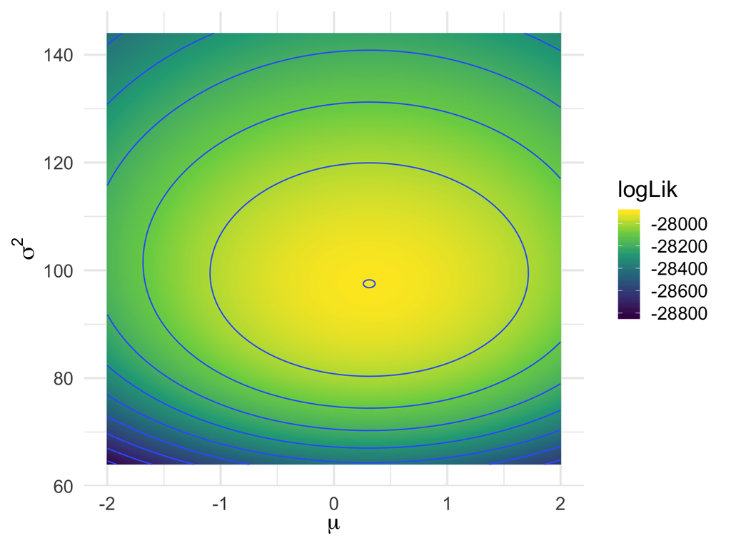

```r
# draw a heatmap of the log-likelihood values
ggplot(search_space, aes(mu, sigma2, fill = logLik)) +
  geom_raster() +
  geom_contour(aes(z = logLik)) +
  scale_fill_continuous(type = "viridis") +
  labs(x = expression(mu),
       y = expression(sigma^2))
```

```r
mean(y)
```

```
## [1] 0.311
```

```r
var(y)
```

```
## [1] 97.5
```

## Newton-Raphson hill climber

- Roots
- Approximate methods
- Newton-Raphson (Newton’s method)

## Description of algorithm

$$\begin{eqnarray}
0 & \cong & f(x_0) + \frac{f^{'}(x_0)}{1} (x_1 - x_0)
\end{eqnarray}$$

$$\begin{eqnarray}
x_1 & \cong & x_0 - \frac{f(x_0)}{f'(x_0)}
\end{eqnarray}$$

$$x_{n+1} \cong x_n - \frac{f(x_n)}{f'(x_n)}$$

## Implementation in R

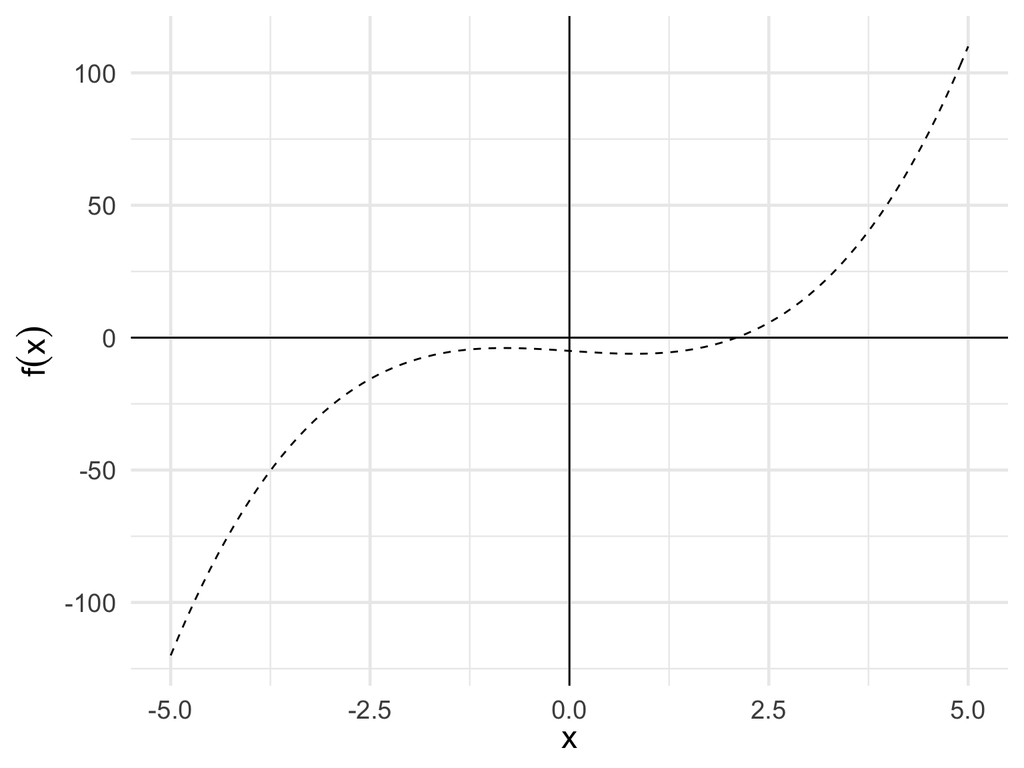

```r
# define the function
func2 <- function(x) {
  x^3 - 2 * x - 5
}

# draw a plot of the function
range <- data_frame(x = c(-5, 5))

f0 <- range %>%
  ggplot(aes(x)) +
  stat_function(fun = func2, size = .5, linetype = 2) +
  geom_hline(yintercept = 0) +
  geom_vline(xintercept = 0) +
  labs(x = expression(x),
       y = expression(f(x)))
f0
```

```r
uniroot(func2, interval = c(2, 3))
```

```
## $root
## [1] 2.09
##
## $f.root
## [1] -0.000115
##
## $iter
## [1] 5
##
## $init.it
## [1] NA
##
## $estim.prec
## [1] 6.1e-05
```

## Implementation in R

```r
# f - the function to optimize
# a - lower bound for the search
# b - upper bound for the search
# tol - tolerance (stopping criteria for the algorithm)
# n - maximum number of iterations to attempt. will not exceed even if
#     tolerance is not achieved

newton_raphson <- function(f, a, b, tol = 1e-5, n_iter = 1000) {
  require(numDeriv) # Package for computing f'(x)

  x0 <- a # Set start value to supplied lower bound
  k <- vector("numeric", length = n_iter) # Initialize for iteration results

  # Check the upper and lower bounds to see if approximations result in 0
  fa <- f(a)
  if (fa == 0.0) {
    return(a)
  }

  fb <- f(b)
  if (fb == 0.0) {
    return(b)
  }

  for (i in 1:n_iter) {
    dx <- genD(func = f, x = x0)$D[1] # First-order derivative f'(x0)
    x1 <- x0 - (f(x0) / dx) # Calculate next value x1
    k[[i]] <- x1 # Store x1

    # Once the difference between x0 and x1 becomes sufficiently small, output the results.
    if (abs(x1 - x0) < tol) {
      root.approx <- x1
      res <- list('root approximation' = root.approx, 'iterations' = k[1:i])
      return(res)
    }
    # If Newton-Raphson has not yet reached convergence set x1 as x0 and continue
    x0 <- x1
  }
  print('Too many iterations in method')
}
```

```r
newton_raphson(f = func2, a = 2, b = 3)
```

```
## $`root approximation`
## [1] 2.09
##
## $iterations
## [1] 2.10 2.09 2.09 2.09
```

## Gradient descent

- Similar to Newton-Raphson
- Step size is proportional to the negative of the gradient of the function at the current point

  $$\mathbf{a}_{n+1} = \mathbf{a}_n-\gamma\nabla F(\mathbf{a}_n)$$

  $$\mathbf{x}_{n+1}=\mathbf{x}_n-\gamma_n \nabla F(\mathbf{x}_n),\ n \ge 0$$

  $$f(\mathbf{x}_0)\ge f(\mathbf{x}_1)\ge f(\mathbf{x}_2)\ge \cdots$$
- Good for convex functions with easily calculated gradients

## Implementation in R

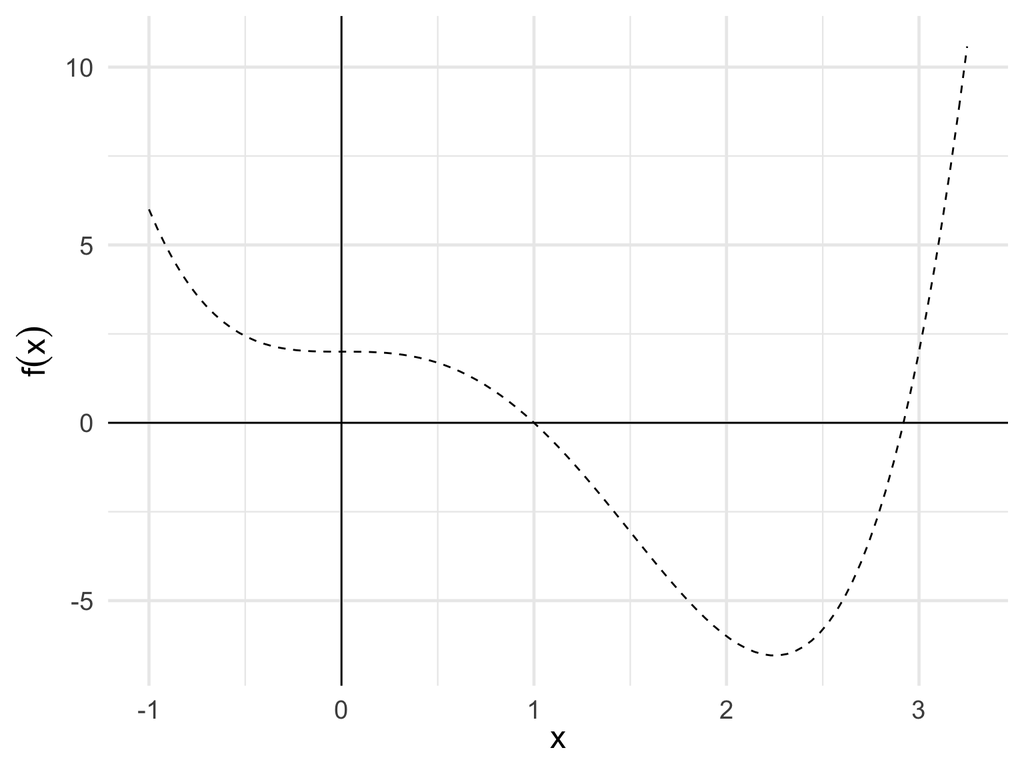

```r
# define the function
obj_func <- function(x) {
  x^4 - 3 * x^3 + 2
}

# draw a plot of the function
range <- data_frame(x = c(-1, 3.25))

f0 <- range %>%
  ggplot(aes(x)) +
  stat_function(fun = obj_func, size = .5, linetype = 2) +
  geom_hline(yintercept = 0) +
  geom_vline(xintercept = 0) +
  labs(x = expression(x),
       y = expression(f(x)))
f0
```

## Implementation in R

$$\nabla f(x) = 4x^3 - 9x^2 = 0$$

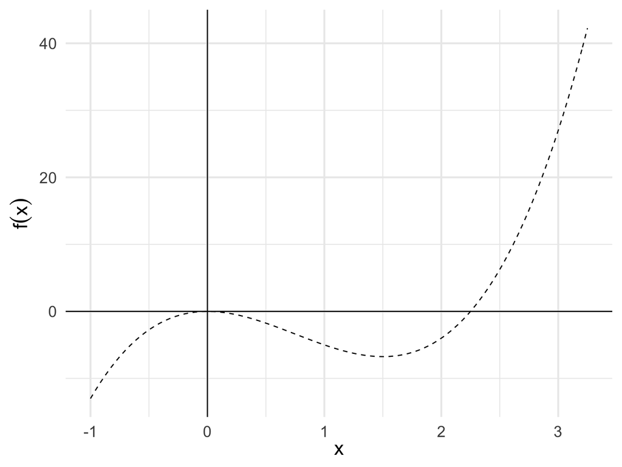

```r
# define the gradient
gradient <- function(x) {
  (4 * x^3) - (9 * x^2)
}

f0 <- range %>%
  ggplot(aes(x)) +
  stat_function(fun = gradient, size = .5, linetype = 2) +
  geom_hline(yintercept = 0) +
  geom_vline(xintercept = 0) +
  labs(x = expression(x),
       y = expression(f(x)))
f0
```

## Implementation in R

```r
# func - the function to optimize
# grad - gradient of the function to optimize
# stepsize - size of each step
# tol - tolerance (stopping criteria for the algorithm)
# iter - maximum number of iterations to attempt. will not exceed even if
#        tolerance is not achieved

grad_desc <- function(func, grad, stepsize = 0.003, tol = 1e-5, iter = 500){
  # randomly initialize a value to x
  set.seed(100)
  x <- floor(runif(1)*10)

  # create a vector to contain all xs for all steps
  x.All <- vector("numeric", iter)

  # gradient descent method to find the minimum
  for(i in 1:iter){
    x1 <- x - stepsize * grad(x)
    x.All[[i]] <- x1

    # Once the difference between x0 and x1 becomes sufficiently small, output the results.
    if (abs(x - x1) < tol) {
      root.approx <- x
      res <- list('root approximation' = root.approx, 'iterations' = x.All[1:i])
      return(res)
    }

    # If gradient descent has not yet reached convergence set x as x0 and continue
    x <- x1
  }

  print('Too many iterations in method')
}

grad_desc(func = obj_func, grad = gradient)
```

```
## $`root approximation`
## [1] 2.25
##
## $iterations
##   [1] 2.92 2.85 2.79 2.74 2.70 2.66 2.62 2.59 2.56 2.54 2.52 2.50 2.48 2.46
##  [15] 2.45 2.43 2.42 2.41 2.40 2.39 2.38 2.37 2.36 2.35 2.35 2.34 2.33 2.33
##  [29] 2.32 2.32 2.31 2.31 2.31 2.30 2.30 2.30 2.29 2.29 2.29 2.29 2.28 2.28
##  [43] 2.28 2.28 2.28 2.27 2.27 2.27 2.27 2.27 2.27 2.27 2.27 2.26 2.26 2.26
##  [57] 2.26 2.26 2.26 2.26 2.26 2.26 2.26 2.26 2.26 2.26 2.26 2.26 2.26 2.26
##  [71] 2.25 2.25 2.25 2.25 2.25 2.25 2.25 2.25 2.25 2.25 2.25 2.25 2.25 2.25
##  [85] 2.25 2.25 2.25 2.25 2.25 2.25 2.25 2.25 2.25 2.25 2.25 2.25 2.25 2.25
##  [99] 2.25 2.25 2.25 2.25 2.25 2.25 2.25 2.25 2.25 2.25 2.25 2.25 2.25 2.25
## [113] 2.25 2.25 2.25 2.25 2.25 2.25 2.25 2.25 2.25 2.25 2.25 2.25 2.25 2.25
## [127] 2.25
```

## `optimize()` and `optim()`

- `optim()`
- `optimize()`

## Example: one-dimensional utility

```r
politician.utility <- function(policy.content){
        politician.support <- -(policy.content - 1)^2 + 8
        return(politician.support)
}
```

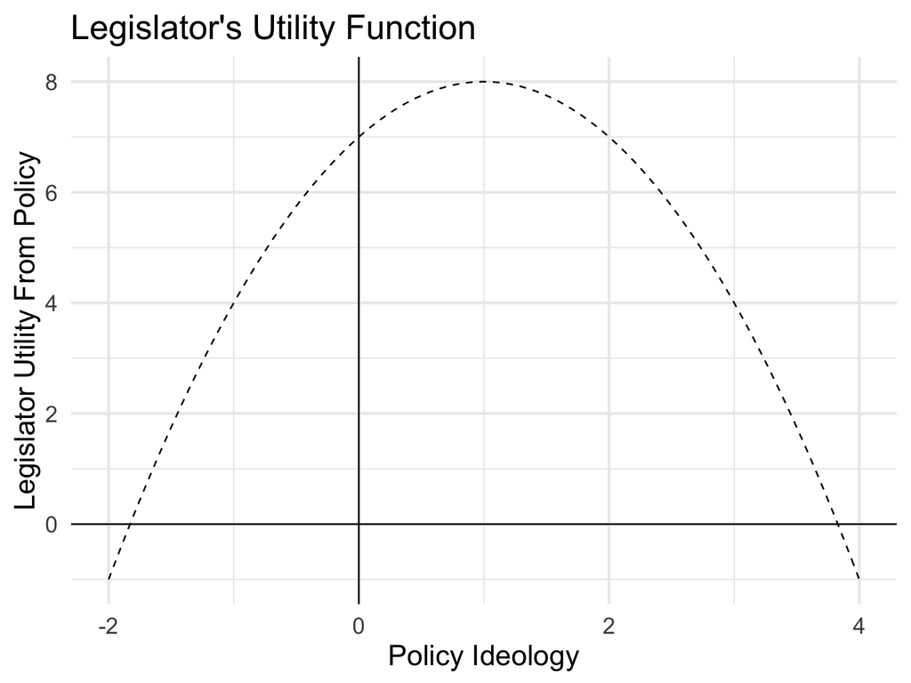

```r
range <- data_frame(x = c(-2, 4))

range %>%
  ggplot(aes(x)) +
  stat_function(fun = politician.utility, size = .5, linetype = 2) +
  geom_hline(yintercept = 0) +
  geom_vline(xintercept = 0) +
  labs(title = "Legislator's Utility Function",
       x = "Policy Ideology",
       y = "Legislator Utility From Policy")
```

## Example: one-dimensional utility

```r
optimize(f = politician.utility, interval = c(-2, 4), maximum = TRUE)
```

```
## $maximum
## [1] 1
##
## $objective
## [1] 8
```

## Example: two-dimensional utility

```r
politician.utility.2d <- function(params){
  # split parameters
  economic.content <- params[1]
  social.content <- params[2]

  # calculate utility
  politician.support <- (-(economic.content - 1)^2 + 8 ) + (-(social.content + 2)^2 + 8)
  return(politician.support)
}
```

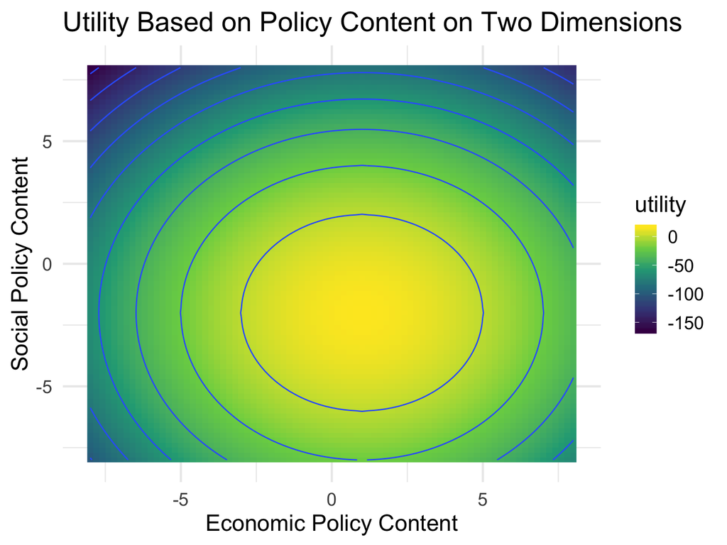

```r
# generate data values
expand.grid(economic.substance = seq(from=-8,to=8, by=.2),
            social.substance = seq(from=-8, to=8, by=.2)) %>%
  as_tibble %>%
  mutate(utility = map2_dbl(economic.substance, social.substance,
                            ~ politician.utility.2d(c(.x, .y)))) %>%
  ggplot(aes(economic.substance, social.substance, fill = utility)) +
  geom_raster() +
  geom_contour(aes(z = utility)) +
  scale_fill_continuous(type = "viridis") +
  labs(title = "Utility Based on Policy Content on Two Dimensions",
       x = "Economic Policy Content",
       y = "Social Policy Content")
```

## Example: two-dimensional utility

```r
optim(par = c(-1, 0), fn = politician.utility.2d, control = list(fnscale = -1))
```

```
## $par
## [1]  1 -2
##
## $value
## [1] 16
##
## $counts
## function gradient
##       61       NA
##
## $convergence
## [1] 0
##
## $message
## NULL
```